# Система рекомендаций комиксов

Anna Pirogova

### Предобработка

Шаги по предобработке данных:

- добавление в датасет с отзывами трех тестовых пользователей (с помощью excel и функции rand.between для выставления рандомных оценок) (файл goodread_reviews_test2.xlsx прикреплен).
- текстовый анализ: тексты описаний комиксов были разбиты на слова, создана переменная, показывающая средний сентимент комикса.

```r
library(stringr)
library(dplyr)
library(ggplot2)
library(tidytext)
library(recommenderlab)
library(ggraph)
library(igraph)
library(tidyr)
library(readxl)
library(kableExtra)
load("~/shared/minor2_2020/data/good_read/books_g_5.RData")
goodread_reviews <- read_excel("~/my/project/goodread_reviews_test2.xlsx")
```

Обработка данных:

- меняем тип переменных на правильный, чтобы в дальнейшем их можно было использовать при создании content-based системы.

```r
goodread_comics$publication_year=as.numeric(goodread_comics$publication_year)
goodread_comics$average_rating=as.numeric(goodread_comics$average_rating)
goodread_comics$num_pages=as.numeric(goodread_comics$num_pages)
goodread_comics$ratings_count=as.numeric(goodread_comics$ratings_count)
```

Sentiment анализ описаний комиксов:

- берется переменная description из датасета goodread_comics.
- после получения сентиментов слов полученные числовые значения объединяются и считается средний сентимент описания.
- полученная переменная будет использована в построении рекомендательной системы.

```r
#оставляем в датасете только столбцы с id книги и её описанием
comics = goodread_comics %>% select(book_id, description)

#удаляем пунктуацию, лишние пробелы, заглавные буквы и числа
comics$description = str_replace_all(comics$description, "[:punct:]+", " ")
comics$description = str_replace_all(comics$description, " ", " ")
comics$description = str_to_lower(comics$description)
comics$description =str_replace_all(comics$description, "[[:punct:]]", "")
comics$description = str_replace_all(comics$description, "[[:digit:]]", "")

# подгрузка словаря стоп-слов
stopw = data.frame(words = stopwords::stopwords("en"))
#разбиваем каждое описание на отдельные слова и избавляемся от стоп-слов
comics_words = comics %>% unnest_tokens(words, description, token = "words") %>% anti_join(stopw)

#лемматизация - приводим полученные слова к начальной форме
#install.packages('textstem')
library(textstem)
comics_words$lem = lemmatize_words(comics_words$words)

#подгружаем словарь с тональностью слов
sent = get_sentiments("afinn")

#объединяем наш датасет со словарем, чтобы присвоить словам численные значения их сентимента
description.sent = comics_words %>%
inner_join(sent, by = c("lem" = "word"))

#группируем по id книги и суммируем значения сентимета для каждого описания
description.sent$value = as.numeric(description.sent$value)
description.sent = description.sent %>% group_by(book_id) %>% summarise(value)
mean_desc_sent = aggregate(description.sent, list(description.sent$book_id), mean)
mean_desc_sent = mean_desc_sent %>% select(- Group.1)

#объединяем полученные значения с изначальным датасетом, чтобы получить новую переменную, с которой теперь можно работать.
goodread_comics = left_join(goodread_comics, mean_desc_sent)
goodread_comics$value=goodread_comics$value %>% replace_na('0')
goodread_comics$value=round(as.numeric(goodread_comics$value),1)
```

**Сетевой анализ:**

- Не дал значимых результатов при тех методах, которые были использованы в анализе.
- Ранее была визуализирована сеть, размеры вершин которой зависели от числа связей одной вершины с другой (degree), а их цвет зависел от параметра betweeness, в финальной версии мы отказались от такой визуализиции в силу ее бесполезности
- Сеть была переписана, теперь вместо average_rating было принято решение сперва посчитать количество оценек, а потом их включить в оценку по косинусному расстоянию
- Первый график снизу отображает сеть комиксов
- Был использован способ walktrap.community для разделения сети на сообщества в 6 шагов, было выделено 4 сообщества по новой сети, что дает нам лишь информацию о том, что книги тесно связаны между собой и их тяжело разделить.(второй график снизу)
- Ниже вы можете видеть значение модулярности
- При использовании перечисленных выше параметров нам не удалось получить какую-либо значимую информацию для написания рекомендательной системы
- Выводы из сетевого анализа: 1) самый важный по битвинности комикс - Legion of Super-Heroes, Vol. 1: Hostile World 2)комиксы “Alice in the Country of Clover: Cheshire Cat Waltz, Vol. 01”, “Chew, Vol. 12: Sour Grapes”, “Fables, Vol. 9: Sons of Empire” обладают наименьшей близостью 3) Действительно, показатель dergee показывает, что бОльшая часть книг тесно связаны друг с другом. Более того показатель betweenness позволил нам взглянуть на самые значимые вершины в терминах посредничества. Это все дало некоторую информацию о датасете, но к сожалению, мы не смогли извлечь полезную информацию для рекомендательных систем.
- Было принято решение не включать сетевой анализ в презентацию проекта.

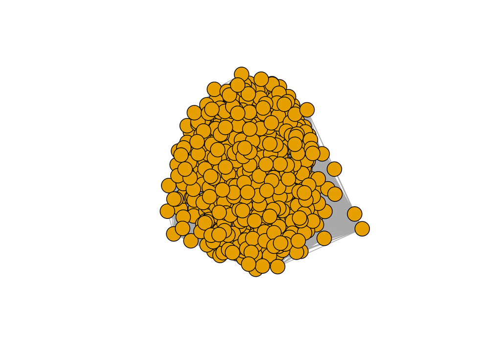

```r
#Отберем некоторые переменные из изначатьного датасета, чтобы затем использовать их для косинусного расстояния. Переводим датаест в формат матрицы
Newdata = goodread_reviews %>%
    group_by(book_id) %>%
    count(rating, sort=TRUE) %>%
    cast_sparse(book_id, rating, n) %>%
  as.matrix()

#Считаем косинусное расстояние - похожесть книг
Newdata = lsa::cosine(t(Newdata))
for(i in 1:501){for(j in 1:501){Newdata[i,j] = ifelse(Newdata[i,j] < 0.3, 0, Newdata[i,j])}}
diag(Newdata) = 0

#Посмотрим на кусочек полученной матрицы
#Newdata[10:15,10:15]

#Создаем сеть
network <- graph_from_adjacency_matrix(Newdata, weighted = TRUE, mode = "undirected")
set.seed(12)
c <- layout.fruchterman.reingold(network)
plot(network, vertex.label = NA, layout = c)
```

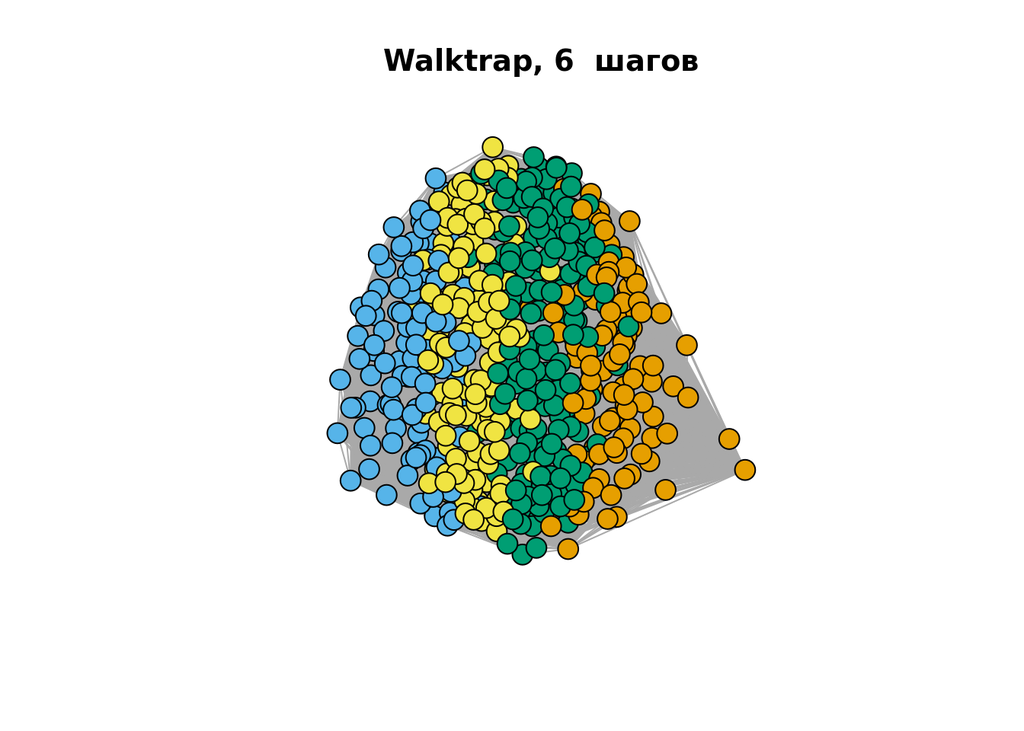

```r
#Визуализируем сообщества, на которые можно разделить полученную сеть
wtcommune = igraph::cluster_walktrap(network, steps = 6)
plot(network,
     vertex.label = NA,
     vertex.color = wtcommune$membership,
     vertex.size = 10,
     layout = c,
     main = "Walktrap, 6  шагов")
```

```r
modularity(wtcommune)
```

```
## [1] 0.02739335
```

```r
#Создадим датасет со всеми метриками графа (degree, betweenness, closeness)
library(DT)
network_degree = degree(network)
network_betweenness = betweenness(network)
network_closeness = closeness(network)
metrics_network = data.frame(Degree = network_degree, Betweenness = network_betweenness, Closeness = network_closeness)

#Битвинность
#options(scipen=231)
#betw = igraph::betweenness(network)
#head(sort(betw, decreasing = TRUE), n=12) #Показывает, что самый важный по битвинности комикс -- 13228289. Давайте взглянем на его название
#goodread_comics %>% filter(book_id == 13228289) %>% select(book_id, title, publisher)

#Близость
#clos = igraph::closeness(network)
#head(sort(clos)) #Показывает, что книги "31387202", "158988", "13168217" обладают наименьшей близостью
#goodread_comics %>% filter(book_id == 31387202 | book_id == 158988 | book_id == 13168217) %>% select(book_id, title, publisher)

#datatable(metrics_network)
#Микро-вывод: Действительно, показатель dergee показывает, что бОльшая часть книг тесно связаны друг с другом. Более того показатель betweenness позволил нам взглянуть на самые значимые вершины в терминах посредничества. Но а самыми далекими от всей сети оказались книги "31387202", "158988", "13168217". Это все дало некоторую информацию о датасете, но к сожалению, мы не смогли извлечь полезную информацию для рекомендательных систем.
```

### Коллаборативная фильтрация

Использован метод UBCF, поскольку при сравнении формальных показателей RMSE, MSE и MAE было выяснено, что этот метод имеет более низкий показатели, чем IBCF.

```r
#убираем лишние данные
ratings = select(goodread_reviews, -date_added,-review_id,-review_text)
# таблица в широком формате
library(tidyr)
rates = pivot_wider(ratings, names_from = book_id, values_from = rating)
#сохраним имена пользователей и удалим столбец с id пользователей
userNames = rates$user_id
rates = select(rates, -user_id)
library(recommenderlab)
# преобразование таблицы данных в матрицу
rates = as.matrix(rates)
rownames(rates) = userNames
# преобразование матрицы в realRatingMatrix
r = as(rates, "realRatingMatrix")
#Отберем только строки и столбцы с нужным количеством оценок
ratings_comics2 <- r[rowCounts(r) > 15, colCounts(r) > 15]

#Разделение на тестовую и обучающую выборку
set.seed(100)
eval_sets <- evaluationScheme(data = ratings_comics2,
                              method = "split",
                              train = 0.8, # доля обучающей выборки
                              given = 8, # сколько оценок используется для  предсказания
                              goodRating = 4) # если предсказанная оценка < 4, то фильм не рекомендуем

# Построение модели методом UBCF
recc_model_ev_ubcf <- Recommender(data = getData(eval_sets, "train"), method = "UBCF",parameter = list(nn = 12))
recc_predicted_ev_ubcf <- predict(
    object = recc_model_ev_ubcf,
    newdata = getData(eval_sets, "known"),
    n = 6,
    type = "ratings")
#оцениваем качество предсказания для ubcf модели
eval_accuracy_ubcf <- calcPredictionAccuracy(x = recc_predicted_ev_ubcf,
                                         # predicted values
                                         data = getData(eval_sets, "unknown"),
                                         byUser = F) # not averaging for each user

# Что делать, если у пользователя слишком мало отзывов? В таком случае стоит порекомендовать ему те комиксы, которые имеют наилучший рейтинг и при этом является наиболее просматриваемыми, то есть на них много отзывов. Создадим для этого список из 5 комиксов, на которые много отзывов и высокая средняя оценка.

# создадим новый дата-фрейм, в котором будут записаны лучшие комиксы
best_comics = goodread_comics
# конвертируем переменные average rating и ratings count в числовой вектор
best_comics$average_rating = as.numeric(best_comics$average_rating)
best_comics$ratings_count = as.numeric(best_comics$ratings_count)
# ранжируем комиксы по количеству отзывов и рейтингу
best_comics = best_comics %>%
  mutate(list = (best_comics$average_rating)*(best_comics$ratings_count)) %>%
  arrange(desc(list))
# отбираем топ 5 с наивысшей средней оценкой
best_comics = head(best_comics, n=5) %>% select(-list) %>% arrange(desc(average_rating))
comics_list<-best_comics$title
```

**Функция для рекомендации CF**

- поскольку модель, построенная методом UBCF имеет меньший показатель ошибки, мы строим функцию тем же методом.
- Входные данные - id пользователя
- пользователь получает 10 рекомендаций.
- если у пользователя слишком мало данных или он впервые на платформе рекомендуем ему список из 5 лучших комиксов.

```r
# функция для рекомендации CF
getComics=function(user_id, num = 10){
  recc_model_ev_ubcf <- Recommender(data = ratings_comics2, method = "UBCF",parameter = list(nn = 14))

  recc_predicted <-
  predict(
    object = recc_model_ev_ubcf,
    newdata = ratings_comics2,
    n = num
  )
recc_user <- recc_predicted@items[[user_id]]
comics_user <- recc_predicted@itemLabels[recc_user]
names_comics_user <- goodread_comics$title[match(comics_user,goodread_comics$book_id)]

if (rlang::is_empty(names_comics_user) == T){
  comics_list
} else {
  data.frame(title = matrix(unlist(names_comics_user), nrow=5, byrow=TRUE),stringsAsFactors=FALSE)

}
}
```

**Оценивание рекомендации:**

- Оценивание рекомендаций для этой системы проводилось несколькими способами: формальные показатели RMSE, MSE, MAE (код можно посмотреть в чанке с коллаборативной фильтрацией) - значения RMSE 1.2333071, MSE 1.5210463, MAE 0.9585269.
- Второй способ - внутренняя пользовательская оценка с добавлением тестовых пользователей в датасет. Подробнее этот метод описан в разделе с примерами.
- Результаты внутренней пользовательской оценки наша команда оценила как хорошие.

### Content-based рекомендация

- для того, чтобы сфоримровать набор признаков, характеризующих комиксы, и важных для построения рекомендаций, был проведен качественный разведовательный анализ.
- Значимыми оказались следующие переменные:
  - полки 1-3
  - показатель рейтинга > 3
  - издатель
  - среднее значение тональности (на основе сентимент-анализа).
- в основе системы матрица схожести, на основе который “находятся” наиболее похожие по выбранным переменным комиксы.
- входными данными для построенной функции является id пользователя.

```r
rev = goodread_reviews %>% rename(id = book_id) %>% group_by(id) %>% summarise(mrat = round(mean(rating), 2))
cbcom = goodread_comics %>% filter(ratings_count >= 150) %>% transmute(id = book_id, title = title_without_series, s1 = popular_shelves.1.name, s2 = popular_shelves.2.name, s3 = popular_shelves.3.name,y=publication_year,v=value,n=num_pages,p=publisher) %>% left_join(rev)
cbcom <- subset(cbcom, p != "")
#cbcom = cbcom  %>% mutate(g=c(s1,s2,s3,p))

polka = cbcom %>% group_by(id) %>% summarise(shelve = c(s1, s2, s3,p))
compw = cbcom %>% left_join(polka) %>% select(-s1, -s2, -s3,-p) %>% mutate(pv = 1) %>% pivot_wider(names_from = shelve, values_from = pv, values_fill = 0)
rown = compw$id
compw = compw %>% select(-id, -title)
rownames(compw) = rown
sim = lsa::cosine(t(as.matrix(compw)))
diag(sim) = 0
```

Функция для рекомендации CB: + входные данные - id пользователя + пользователь получает 10 рекомендаций. + если у пользователя слишком мало данных или он впервые на платформе рекомендуем ему список из 5 лучших комиксов.

```r
get_similar = function(u_id){
u = goodread_reviews %>% filter(user_id == u_id & (rating == 5 | rating == 4))
u = cbcom %>% filter(id %in% u$book_id)
if (nrow(u) == 0) {
recommend = comics_list
} else {
simCut = sim[,as.character(u$id)]
mostSimilar = head(sort(simCut, decreasing = T), 10)
a = which(simCut %in% mostSimilar, arr.ind = T)
index = arrayInd(a, .dim = dim(sim))
result = rownames(sim)[index[,1]]
recommend = filter(cbcom, as.character(id) %in% result) %>% select(title)
}
recommend
}
```

**Оценивание рекомендации:**

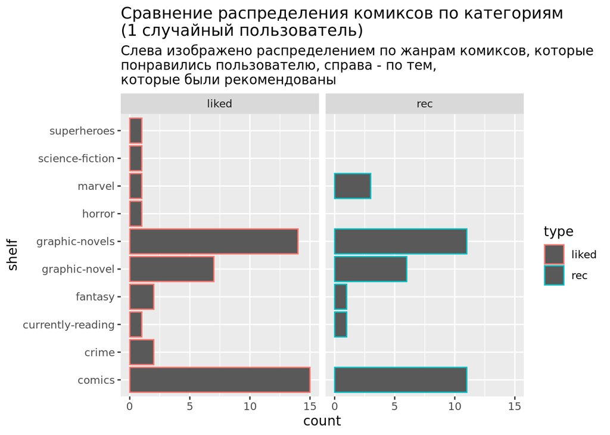

```r
#проверка на адекватность
result=get_similar("2a1eed8348a005c77251928b500f17e8") %>% left_join(cbcom)
liked=goodread_reviews %>% filter(user_id=="2a1eed8348a005c77251928b500f17e8",rating>3) %>% mutate(id=book_id) %>% select(-book_id,-review_id,-date_added,-review_text,-user_id) %>% left_join(cbcom) %>% arrange(-rating) %>% na.omit()
users_test=goodread_reviews %>% group_by(user_id) %>% summarize(cnt=n()) %>% arrange(-cnt)

liked3=liked %>% select(title,p,s1,s2,s3)

liked_g = liked %>% group_by(id) %>% summarise(shelf = c(s1, s2, s3)) %>% mutate(type="liked")


result_g= result %>% group_by(id) %>% summarise(shelf = c(s1, s2, s3)) %>% mutate(type="rec")
total=rbind(result_g,liked_g)
ggplot(data=total)+geom_histogram(aes(x=shelf,color=type),stat="count")+facet_grid(~type)+coord_flip()+
  ggtitle(label = 'Сравнение распределения комиксов по категориям\n(1 случайный пользователь)', subtitle = 'Слева изображено распределением по жанрам комиксов, которые\nпонравились пользователю, справа - по тем,\nкоторые были рекомендованы')
```

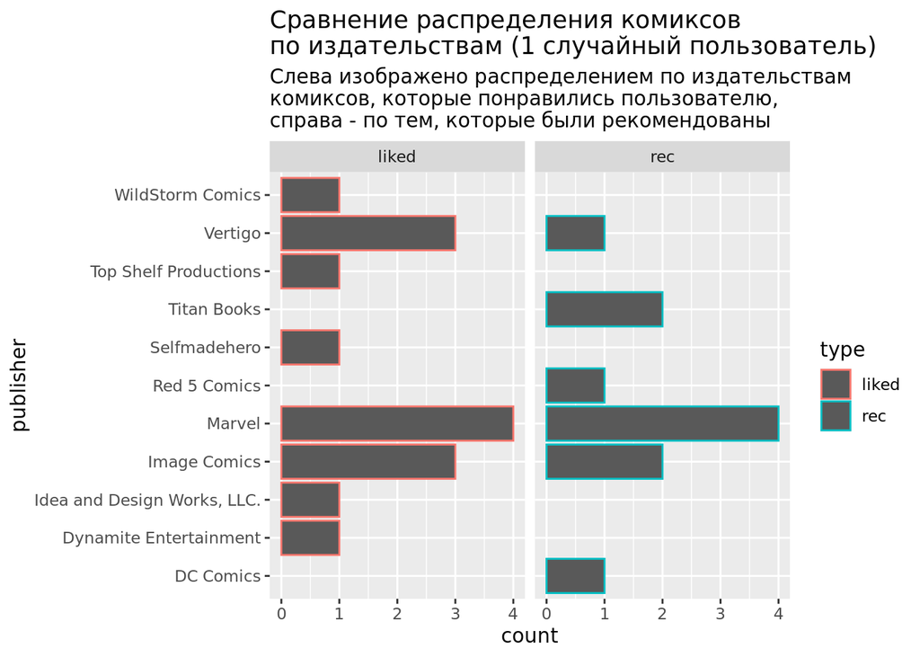

```r
liked_p=liked %>% group_by(id) %>% summarise(publisher=p) %>% mutate(type="liked")
result_p=result %>% group_by(id) %>% summarise(publisher=p) %>% mutate(type="rec")
total2=rbind(result_p,liked_p)
ggplot(data=total2)+geom_histogram(aes(x=publisher,color=type),stat="count")+facet_grid(~type)+coord_flip()+
  ggtitle(label = 'Сравнение распределения комиксов\nпо издательствам (1 случайный пользователь)', subtitle = 'Слева изображено распределением по издательствам\nкомиксов, которые понравились пользователю,\nсправа - по тем, которые были рекомендованы')
```

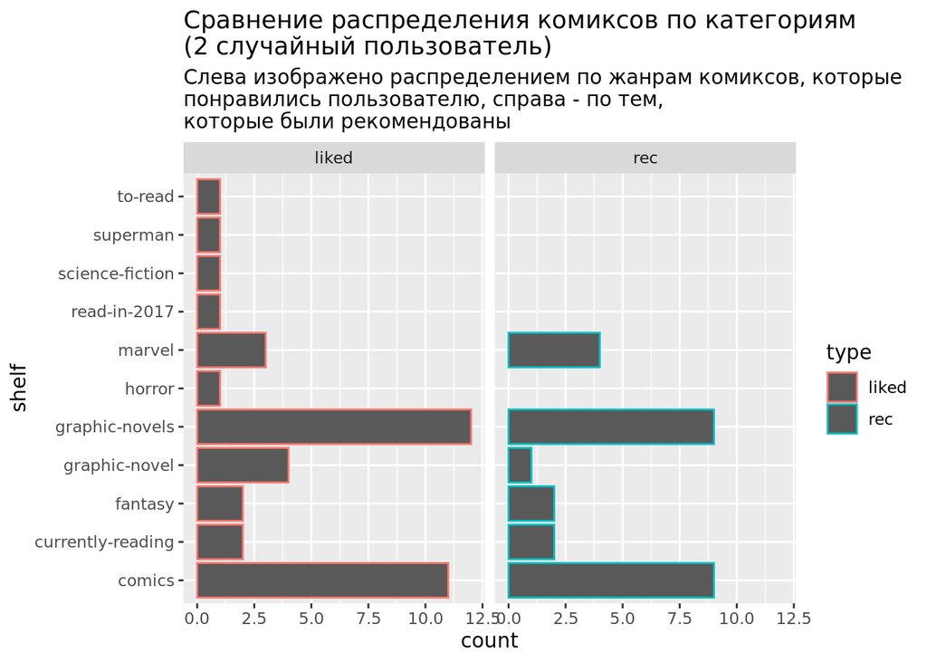

```r
result=get_similar("6852e76e61b386ae76b5b9799b8f6ca5") %>% left_join(cbcom)
liked=goodread_reviews %>% filter(user_id=="6852e76e61b386ae76b5b9799b8f6ca5",rating>3) %>% mutate(id=book_id) %>% select(-book_id,-review_id,-date_added,-review_text,-user_id) %>% left_join(cbcom) %>% arrange(-rating) %>% na.omit()
users_test=goodread_reviews %>% group_by(user_id) %>% summarize(cnt=n()) %>% arrange(-cnt)

liked3=liked %>% select(title,p,s1,s2,s3)

liked_g = liked %>% group_by(id) %>% summarise(shelf = c(s1, s2, s3)) %>% mutate(type="liked")


result_g= result %>% group_by(id) %>% summarise(shelf = c(s1, s2, s3)) %>% mutate(type="rec")
total=rbind(result_g,liked_g)
ggplot(data=total)+geom_histogram(aes(x=shelf,color=type),stat="count")+facet_grid(~type)+coord_flip()+
  ggtitle(label = 'Сравнение распределения комиксов по категориям\n(2 случайный пользователь)', subtitle = 'Слева изображено распределением по жанрам комиксов, которые\nпонравились пользователю, справа - по тем,\nкоторые были рекомендованы')
```

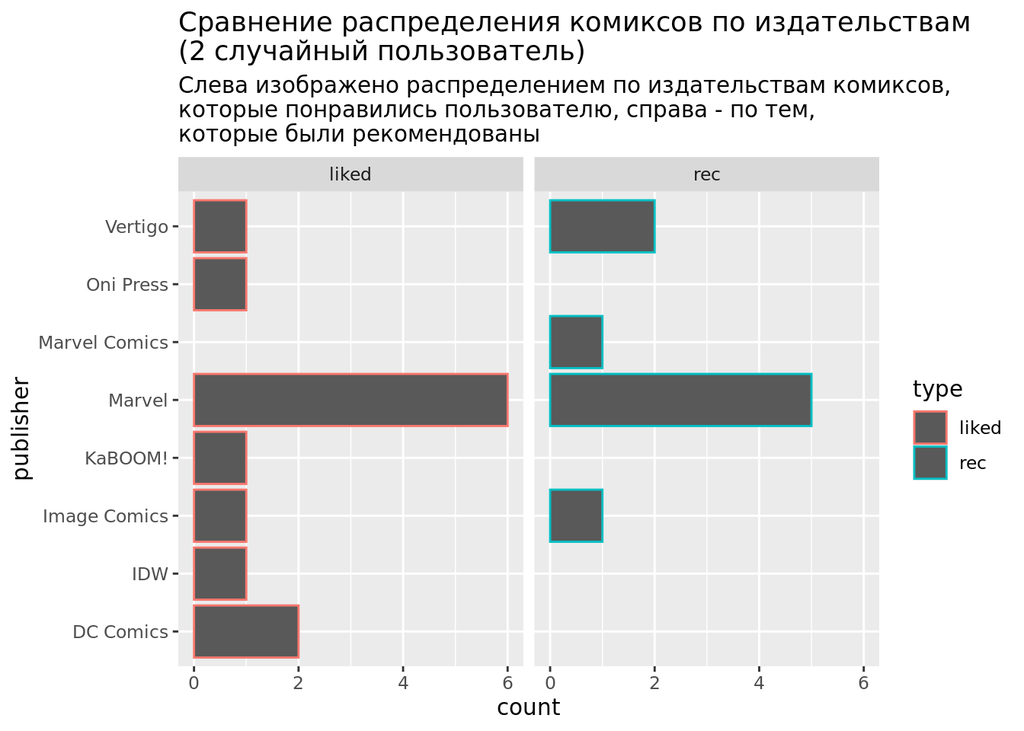

```r
liked_p=liked %>% group_by(id) %>% summarise(publisher=p) %>% mutate(type="liked")
result_p=result %>% group_by(id) %>% summarise(publisher=p) %>% mutate(type="rec")
total2=rbind(result_p,liked_p)
ggplot(data=total2)+geom_histogram(aes(x=publisher,color=type),stat="count")+facet_grid(~type)+coord_flip()+
  ggtitle(label = 'Сравнение распределения комиксов по издательствам\n(2 случайный пользователь)', subtitle = 'Слева изображено распределением по издательствам комиксов,\nкоторые понравились пользователю, справа - по тем,\nкоторые были рекомендованы')
```

##### **Примеры collaborative filtering**

###### **Наши примеры**

(все примеры из peer review были про content-based систему, поэтому в этом разделе есть только наши примеры)

Мы создали двух тестовых пользователей, поставили оценки случайным образом и записали их в датасет.

Что мы ожидаем от хорошей рекомендации:

- похожие издательства
- похожие названия полок

###### **Пример1 тестовый пользователь 1**

- id aa999 (25 оценок) -оценивал комиксы vertigo и marvel, дополнительно оценил 2 самых популярных комикса и 3 рандомных, названия полок - graphic-novels, comics, marvel.
- в таблицах ниже вы можете видеть результат рекомендаций.
- мы оцениваем рекомендация как хорошую, поскольку видим: издательство Marvel. Полки comics, graphic novels и marvel.

```r
liked_test1=goodread_reviews %>% filter(user_id=="aa999",rating>3) %>% mutate(id=book_id) %>% select(-book_id,-review_id,-date_added,-review_text,-user_id) %>% left_join(cbcom) %>% arrange(-rating) %>% na.omit() %>% select(-rating,-id,-y,-v,-n,-mrat)


liked_test1 %>% kable(caption = "**Пример 1: характеристики понравившихся комиксов**") %>% kable_classic(full_width = F, html_font = "Cambria") %>% row_spec(row = 0,color="white",background = "#5e4749") %>% row_spec(1, color="#5e4749", background="#e2c9dd") %>% row_spec(3, color="#5e4749", background="#e2c9dd") %>% row_spec(5, color="#5e4749", background="#e2c9dd") %>% row_spec(7, color="#5e4749", background="#e2c9dd") %>% row_spec(9, color="#5e4749", background="#e2c9dd")%>% row_spec(11, color="#5e4749", background="#e2c9dd") %>% row_spec(13, color="#5e4749", background="#e2c9dd") %>%  row_spec(2, color="#5e4749", background="white") %>% row_spec(4, color="#5e4749", background="white") %>% row_spec(6, color="#5e4749", background="white") %>% row_spec(8, color="#5e4749", background="white") %>% row_spec(10, color="#5e4749", background="white") %>%row_spec(12, color="#5e4749", background="white") %>% row_spec(14, color="#5e4749", background="white") %>% kable_paper() %>%  scroll_box(width = "100%", height = "300px")
```

**Пример 1: характеристики понравившихся комиксов**

| title | s1 | s2 | s3 | p |
| --- | --- | --- | --- | --- |
| Fables, Vol. 7: Arabian Nights [and Days] (Fables, #7) | graphic-novels | comics | fantasy | Vertigo |
| Fables, Vol. 10: The Good Prince | fantasy | comics | cómics | Vertigo |
| Hellblazer: Bloodlines | comics | graphic-novels | horror | Vertigo |
| Gwenpool, the Unbelievable, Vol. 2: Head of M.O.D.O.K | comics | graphic-novels | graphic-novel | Marvel |
| Uncanny X-Men: Lovelorn | comics | graphic-novels | x-men | Marvel |
| Civil War: Ms. Marvel | comics | graphic-novels | marvel | Marvel |
| Hawkeye #11 | to-read | marvel | comic | Marvel Comics |
| Scott Pilgrim, Volume 2: Scott Pilgrim vs. The World | graphic-novels | comics | graphic-novel | Oni Press |
| Invincible Iron Man: Ironheart, Volume 1: Riri Williams | graphic-novels | graphic-novel | comics | Marvel |
| Guardians of the Galaxy: New Guard, Volume 1: Emperor Quill | comics | graphic-novels | currently-reading | Marvel |
| PunisherMAX, Vol. 1: Kingpin | comics | graphic-novels | marvel | Marvel |
| Powers, Vol. 9: Psychotic | comics | graphic-novels | graphic-novel | Marvel |
| Ultimate Comics: Spider-Man, by Brian Michael Bendis, Volume 1 | comics | graphic-novels | marvel | Marvel |
| Y: The Last Man, Vol. 8: Kimono Dragons (Y: The Last Man, #8) | graphic-novels | comics | graphic-novel | Vertigo |

```r
result_test_1=getComics(user_id="aa999",num=5) %>% left_join(goodread_comics,by="title") %>% select(title,popular_shelves.1.name,popular_shelves.2.name,popular_shelves.3.name,publisher)
result_test_1 %>% kbl(caption = "**Пример 1: характеристики рекомендованных комиксов**") %>%
kable_classic(full_width = F, html_font = "Cambria") %>% row_spec(row = 0,color="white",background = "#5e4749") %>% row_spec(1, color="#5e4749", background="#e2c9dd") %>% row_spec(3, color="#5e4749", background="#e2c9dd") %>% row_spec(5, color="#5e4749", background="#e2c9dd") %>% row_spec(2, color="#5e4749", background="white") %>% row_spec(4, color="#5e4749", background="white")%>% kable_paper() %>%  scroll_box(width = "100%", height = "300px")
```

**Пример 1: характеристики рекомендованных комиксов**

| title | popular_shelves.1.name | popular_shelves.2.name | popular_shelves.3.name | publisher |
| --- | --- | --- | --- | --- |
| Refresh, Refresh | favorites | graphic-novels | short-stories | First Second |
| Miracleman, Book One: A Dream of Flying | comics | graphic-novels | cómics | Marvel Comics |
| Annihilation, Book One | comics | graphic-novels | marvel | Marvel |
| Deadpool’s Art of War | comics | graphic-novels | marvel | Marvel |
| The Vision, Volume 1: Little Worse Than A Man | comics | graphic-novels | currently-reading | Marvel |

###### **Пример2 тестовый пользователь 2**

- id bbb9999 (18 оценок) - оценил комиксы image comics, DC comics + 1 популярный.
- названия полок - graphic-novels, comics, batman, zombies,dc-comics. Здесь система справилась чуть хуже. Но все жы мы видим издательство Image Comics, а также названия полок comics и graphic novels.

```r
liked_test2=goodread_reviews %>% filter(user_id=="bbb9999",rating>3) %>% mutate(id=book_id) %>% select(-book_id,-review_id,-date_added,-review_text,-user_id) %>% left_join(cbcom) %>% arrange(-rating) %>% na.omit()%>% select(-rating,-id,-y,-v,-n,-mrat)

liked_test2 %>% kable(caption = "**Пример 2: характеристики понравившихся комиксов**") %>% kable_classic(full_width = F, html_font = "Cambria") %>% row_spec(row = 0,color="white",background = "#5e4749") %>% row_spec(1, color="#5e4749", background="#e2c9dd") %>% row_spec(3, color="#5e4749", background="#e2c9dd") %>% row_spec(5, color="#5e4749", background="#e2c9dd") %>% row_spec(7, color="#5e4749", background="#e2c9dd") %>% row_spec(9, color="#5e4749", background="#e2c9dd")%>% row_spec(11, color="#5e4749", background="#e2c9dd") %>% row_spec(13, color="#5e4749", background="#e2c9dd")%>% row_spec(15, color="#5e4749", background="#e2c9dd")%>% row_spec(17, color="#5e4749", background="#e2c9dd") %>%  row_spec(2, color="#5e4749", background="white") %>% row_spec(4, color="#5e4749", background="white") %>% row_spec(6, color="#5e4749", background="white") %>% row_spec(8, color="#5e4749", background="white") %>% row_spec(10, color="#5e4749", background="white") %>%row_spec(12, color="#5e4749", background="white") %>% row_spec(14, color="#5e4749", background="white")%>% row_spec(16, color="#5e4749", background="white") %>% kable_paper() %>%  scroll_box(width = "100%", height = "300px")
```

**Пример 2: характеристики понравившихся комиксов**

| title | s1 | s2 | s3 | p |
| --- | --- | --- | --- | --- |
| V for Vendetta | graphic-novels | currently-reading | graphic-novel | Vertigo |
| The Walking Dead, Issue #145 | comics | the-walking-dead | zombies | Image Comics |
| The Wicked + The Divine #1 | comics | graphic-novels | graphic-novel | Image Comics |
| Wonder Woman: The Hiketeia | graphic-novels | comics | cómics | DC Comics |
| Starfire, Vol. 1: Welcome Home | comics | graphic-novels | graphic-novel | DC Comics |
| Superman and the Legion of Super-Heroes | comics | graphic-novels | superman | DC Comics |
| Batman: Blind Justice | comics | batman | graphic-novels | DC Comics |
| Batman: The Cult | comics | graphic-novels | batman | DC Comics |
| Zatanna, Vol. 1: The Mistress of Magic | comics | graphic-novels | dc | DC Comics |
| Batman: Crimson Mist | comics | graphic-novels | batman | DC Comics |
| Justice League: Cry for Justice | comics | graphic-novels | dc-comics | DC Comics |
| Prophet, Volume 3: Empire | comics | graphic-novels | science-fiction | Image Comics |
| The Autumnlands, Vol. 2: Woodland Creatures | comics | fantasy | to-read | Image Comics |
| The Walking Dead, Issue #128 | comics | horror | the-walking-dead | Image Comics |
| Aquaman, Vol. 1: The Trench | graphic-novels | comics | dc | DC Comics |
| Superman vs. Muhammad Ali | comics | graphic-novels | superman | DC Comics |
| Wonder Woman: Down to Earth | comics | graphic-novels | wonder-woman | DC Comics |

```r
result_test_2=getComics(user_id="bbb9999",num=5) %>% left_join(goodread_comics,by="title") %>% select(title,popular_shelves.1.name,popular_shelves.2.name,popular_shelves.3.name,publisher)
result_test_2 %>%  kbl(caption = "**Пример 2: Список рекомендаций для пользователя**") %>%
kable_classic(full_width = F, html_font = "Cambria") %>% row_spec(row = 0,color="white",background = "#5e4749") %>% row_spec(1, color="#5e4749", background="#e2c9dd") %>% row_spec(3, color="#5e4749", background="#e2c9dd") %>% row_spec(5, color="#5e4749", background="#e2c9dd") %>% row_spec(2, color="#5e4749", background="white") %>% row_spec(4, color="#5e4749", background="white")%>% kable_paper() %>%  scroll_box(width = "100%", height = "300px")
```

**Пример 2: Список рекомендаций для пользователя**

| title | popular_shelves.1.name | popular_shelves.2.name | popular_shelves.3.name | publisher |
| --- | --- | --- | --- | --- |
| Invincible: Ultimate Collection, Vol. 1 | comics | graphic-novels | graphic-novel | Image Comics |
| Scott Pilgrim, Volume 2: Scott Pilgrim vs. The World | graphic-novels | comics | graphic-novel | Oni Press |
| The Absolute Sandman, Volume Two | comics | graphic-novels | fantasy |  |
| Hellboy, Vol. 10: The Crooked Man and Others (Hellboy, #10) | comics | graphic-novels | horror | Dark Horse Comics |
| Northlanders, Vol. 4: The Plague Widow | comics | graphic-novels | historical-fiction | Vertigo |

###### **Пример3 с новым пользователем**

Введем id пользователя, которого нет в нашем датасете и у которого, соответственно нет оценок. Система порекомендует ему 5 самых высоко оцениваемых и популярных комиксов из нашего датасета, что можно видеть ниже.

```r
getComics("1") %>% kbl(caption = "**Пример 3: Список рекомендаций для нового пользователя**") %>%
kable_classic(full_width = F, html_font = "Cambria") %>% row_spec(row = 0,color="white",background = "#5e4749") %>% row_spec(1, color="#5e4749", background="#e2c9dd") %>% row_spec(3, color="#5e4749", background="#e2c9dd") %>% row_spec(5, color="#5e4749", background="#e2c9dd") %>% row_spec(2, color="#5e4749", background="white") %>% row_spec(4, color="#5e4749", background="white")
```

**Пример 3: Список рекомендаций для нового пользователя**

| x |
| --- |
| Death Note, Vol. 1: Boredom (Death Note, #1) |
| V for Vendetta |
| The Walking Dead, Vol. 02: Miles Behind Us |
| Y: The Last Man, Vol. 8: Kimono Dragons (Y: The Last Man, #8) |
| Rat Queens, Vol. 1: Sass & Sorcery |

##### **Примеры content-based**

###### **Наши примеры**

###### **Пример1 тестовый пользователь 1**

Здесь можно увидеть, что рекомендует система тестовому пользователю (тот же пользователь, что и из примера1 collaborative filtering). Как помним, у id aa999 (25 оценок), оценивал комиксы vertigo и marvel, дополнительно оценил 2 самых популярных комикса и 3 рандомных, названия полок - graphic-novels, comics, marvel. В рекомендациях видим Marcel, Vertigo, DC Comics с полками graphic-novels, comics, marvel. Считаем эту рекомендацию подходящей.

```r
liked_test1=goodread_reviews %>% filter(user_id=="aa999",rating>3) %>% mutate(id=book_id) %>% select(-book_id,-review_id,-date_added,-review_text,-user_id) %>% left_join(cbcom) %>% arrange(-rating) %>% na.omit() %>% select(-rating,-id,-y,-v,-n,-mrat)


liked_test1 %>% kable(caption = "**Пример 1: характеристики понравившихся комиксов**") %>% kable_classic(full_width = F, html_font = "Cambria") %>% row_spec(row = 0,color="white",background = "#5e4749") %>% row_spec(1, color="#5e4749", background="#e2c9dd") %>% row_spec(3, color="#5e4749", background="#e2c9dd") %>% row_spec(5, color="#5e4749", background="#e2c9dd") %>% row_spec(7, color="#5e4749", background="#e2c9dd") %>% row_spec(9, color="#5e4749", background="#e2c9dd")%>% row_spec(11, color="#5e4749", background="#e2c9dd") %>% row_spec(13, color="#5e4749", background="#e2c9dd") %>%  row_spec(2, color="#5e4749", background="white") %>% row_spec(4, color="#5e4749", background="white") %>% row_spec(6, color="#5e4749", background="white") %>% row_spec(8, color="#5e4749", background="white") %>% row_spec(10, color="#5e4749", background="white") %>%row_spec(12, color="#5e4749", background="white") %>% row_spec(14, color="#5e4749", background="white") %>% kable_paper() %>%  scroll_box(width = "100%", height = "300px")
```

**Пример 1: характеристики понравившихся комиксов**

| title | s1 | s2 | s3 | p |
| --- | --- | --- | --- | --- |
| Fables, Vol. 7: Arabian Nights [and Days] (Fables, #7) | graphic-novels | comics | fantasy | Vertigo |
| Fables, Vol. 10: The Good Prince | fantasy | comics | cómics | Vertigo |
| Hellblazer: Bloodlines | comics | graphic-novels | horror | Vertigo |
| Gwenpool, the Unbelievable, Vol. 2: Head of M.O.D.O.K | comics | graphic-novels | graphic-novel | Marvel |
| Uncanny X-Men: Lovelorn | comics | graphic-novels | x-men | Marvel |
| Civil War: Ms. Marvel | comics | graphic-novels | marvel | Marvel |
| Hawkeye #11 | to-read | marvel | comic | Marvel Comics |
| Scott Pilgrim, Volume 2: Scott Pilgrim vs. The World | graphic-novels | comics | graphic-novel | Oni Press |
| Invincible Iron Man: Ironheart, Volume 1: Riri Williams | graphic-novels | graphic-novel | comics | Marvel |
| Guardians of the Galaxy: New Guard, Volume 1: Emperor Quill | comics | graphic-novels | currently-reading | Marvel |
| PunisherMAX, Vol. 1: Kingpin | comics | graphic-novels | marvel | Marvel |
| Powers, Vol. 9: Psychotic | comics | graphic-novels | graphic-novel | Marvel |
| Ultimate Comics: Spider-Man, by Brian Michael Bendis, Volume 1 | comics | graphic-novels | marvel | Marvel |
| Y: The Last Man, Vol. 8: Kimono Dragons (Y: The Last Man, #8) | graphic-novels | comics | graphic-novel | Vertigo |

```r
result_test_44=get_similar("aa999") %>% left_join(goodread_comics,by="title") %>% select(title,average_rating,popular_shelves.1.name,popular_shelves.2.name,popular_shelves.3.name,publisher) %>% kable(caption = "**Пример 1: характеристики рекомендованных комиксов**") %>% kable_classic(full_width = F, html_font = "Cambria") %>% row_spec(row = 0,color="white",background = "#5e4749") %>% row_spec(1, color="#5e4749", background="#e2c9dd") %>% row_spec(3, color="#5e4749", background="#e2c9dd") %>% row_spec(5, color="#5e4749", background="#e2c9dd") %>% row_spec(7, color="#5e4749", background="#e2c9dd") %>% row_spec(9, color="#5e4749", background="#e2c9dd")%>% row_spec(2, color="#5e4749", background="white") %>% row_spec(4, color="#5e4749", background="white") %>% row_spec(6, color="#5e4749", background="white") %>% row_spec(8, color="#5e4749", background="white") %>% row_spec(10, color="#5e4749", background="white") %>% kable_paper() %>%  scroll_box(width = "100%", height = "300px")
result_test_44
```

**Пример 1: характеристики рекомендованных комиксов**

| title | average_rating | popular_shelves.1.name | popular_shelves.2.name | popular_shelves.3.name | publisher |
| --- | --- | --- | --- | --- | --- |
| Fables, Volume 1: Legends in Exile (Fables, #1) | 3.99 | graphic-novels | comics | fantasy | Vertigo |
| Groot | 4.35 | graphic-novels | comics | graphic-novel | Marvel |
| Indestructible Hulk, Volume 1: Agent of S.H.I.E.L.D. | 3.92 | comics | graphic-novels | marvel | Marvel |
| Captain Marvel, Volume 1: In Pursuit of Flight | 3.85 | comics | graphic-novels | graphic-novel | Marvel |
| Hinterkind Vol. 1: The Waking World | 3.20 | graphic-novels | comics | fantasy | Vertigo |
| Mockingbird, Vol. 1: I Can Explain | 4.24 | graphic-novels | comics | graphic-novel | Marvel |
| Fables, Vol. 7: Arabian Nights [and Days] (Fables, #7) | 4.10 | graphic-novels | comics | fantasy | Vertigo |
| Death, Jr. | 3.95 | graphic-novels | comics | graphic-novel | Image Comics |
| Y: The Last Man, Vol. 8: Kimono Dragons (Y: The Last Man, #8) | 4.22 | graphic-novels | comics | graphic-novel | Vertigo |
| Power Girl, Vol. 2: Aliens and Apes | 4.05 | comics | graphic-novels | graphic-novel | DC Comics |

###### **Пример2 тестовый пользователь 2**

Этот пример показывает рекомендации тестовому пользователю 2 (такой же пользователь, как в примере2 collaborative filtering). Напомним, что ему нравились комиксы image comics, DC comics + 1 популярный. Названия полок - graphic-novels, comics, batman, zombies,dc-comics. В рекомендациях только DC Comics и Image Comics, полки называются похожим образом. Считаем, что это рекомендация отличная.

```r
liked_test2=goodread_reviews %>% filter(user_id=="bbb9999",rating>3) %>% mutate(id=book_id) %>% select(-book_id,-review_id,-date_added,-review_text,-user_id) %>% left_join(cbcom) %>% arrange(-rating) %>% na.omit()%>% select(-rating,-id,-y,-v,-n,-mrat)

liked_test2 %>% kable(caption = "**Пример 2: характеристики понравившихся комиксов**") %>% kable_classic(full_width = F, html_font = "Cambria") %>% row_spec(row = 0,color="white",background = "#5e4749") %>% row_spec(1, color="#5e4749", background="#e2c9dd") %>% row_spec(3, color="#5e4749", background="#e2c9dd") %>% row_spec(5, color="#5e4749", background="#e2c9dd") %>% row_spec(7, color="#5e4749", background="#e2c9dd") %>% row_spec(9, color="#5e4749", background="#e2c9dd")%>% row_spec(11, color="#5e4749", background="#e2c9dd") %>% row_spec(13, color="#5e4749", background="#e2c9dd")%>% row_spec(15, color="#5e4749", background="#e2c9dd")%>% row_spec(17, color="#5e4749", background="#e2c9dd") %>%  row_spec(2, color="#5e4749", background="white") %>% row_spec(4, color="#5e4749", background="white") %>% row_spec(6, color="#5e4749", background="white") %>% row_spec(8, color="#5e4749", background="white") %>% row_spec(10, color="#5e4749", background="white") %>%row_spec(12, color="#5e4749", background="white") %>% row_spec(14, color="#5e4749", background="white")%>% row_spec(16, color="#5e4749", background="white") %>% kable_paper() %>%  scroll_box(width = "100%", height = "300px")
```

**Пример 2: характеристики понравившихся комиксов**

| title | s1 | s2 | s3 | p |
| --- | --- | --- | --- | --- |
| V for Vendetta | graphic-novels | currently-reading | graphic-novel | Vertigo |
| The Walking Dead, Issue #145 | comics | the-walking-dead | zombies | Image Comics |
| The Wicked + The Divine #1 | comics | graphic-novels | graphic-novel | Image Comics |
| Wonder Woman: The Hiketeia | graphic-novels | comics | cómics | DC Comics |
| Starfire, Vol. 1: Welcome Home | comics | graphic-novels | graphic-novel | DC Comics |
| Superman and the Legion of Super-Heroes | comics | graphic-novels | superman | DC Comics |
| Batman: Blind Justice | comics | batman | graphic-novels | DC Comics |
| Batman: The Cult | comics | graphic-novels | batman | DC Comics |
| Zatanna, Vol. 1: The Mistress of Magic | comics | graphic-novels | dc | DC Comics |
| Batman: Crimson Mist | comics | graphic-novels | batman | DC Comics |
| Justice League: Cry for Justice | comics | graphic-novels | dc-comics | DC Comics |
| Prophet, Volume 3: Empire | comics | graphic-novels | science-fiction | Image Comics |
| The Autumnlands, Vol. 2: Woodland Creatures | comics | fantasy | to-read | Image Comics |
| The Walking Dead, Issue #128 | comics | horror | the-walking-dead | Image Comics |
| Aquaman, Vol. 1: The Trench | graphic-novels | comics | dc | DC Comics |
| Superman vs. Muhammad Ali | comics | graphic-novels | superman | DC Comics |
| Wonder Woman: Down to Earth | comics | graphic-novels | wonder-woman | DC Comics |

```r
result_test_55=get_similar("bbb9999") %>% left_join(goodread_comics,by="title") %>% select(title,average_rating,popular_shelves.1.name,popular_shelves.2.name,popular_shelves.3.name,publisher)
result_test_55 %>% kable(caption = "**Пример 2: характеристики рекомендованных комиксов**") %>% kable_classic(full_width = F, html_font = "Cambria") %>% row_spec(row = 0,color="white",background = "#5e4749") %>% row_spec(1, color="#5e4749", background="#e2c9dd") %>% row_spec(3, color="#5e4749", background="#e2c9dd") %>% row_spec(5, color="#5e4749", background="#e2c9dd") %>% row_spec(7, color="#5e4749", background="#e2c9dd") %>% row_spec(9, color="#5e4749", background="#e2c9dd")%>% row_spec(2, color="#5e4749", background="white") %>% row_spec(4, color="#5e4749", background="white") %>% row_spec(6, color="#5e4749", background="white") %>% row_spec(8, color="#5e4749", background="white") %>% kable_paper() %>%  scroll_box(width = "100%", height = "300px")
```

**Пример 2: характеристики рекомендованных комиксов**

| title | average_rating | popular_shelves.1.name | popular_shelves.2.name | popular_shelves.3.name | publisher |
| --- | --- | --- | --- | --- | --- |
| Injustice: Gods Among Us: Year Three, Vol. 2 | 3.87 | comics | graphic-novels | dc-comics | DC Comics |
| Batgirl, Vol. 1: The Darkest Reflection | 3.95 | comics | graphic-novels | graphic-novel | DC Comics |
| Birds of Prey, Volume 1: Trouble in Mind | 3.77 | comics | graphic-novels | graphic-novel | DC Comics |
| Snotgirl, Vol. 1: Green Hair Don’t Care | 3.46 | comics | graphic-novels | graphic-novel | Image Comics |
| Justice League, Volume 5: Forever Heroes | 3.71 | comics | graphic-novels | dc | DC Comics |
| Martian Manhunter, Volume 1: The Epiphany | 3.50 | comics | graphic-novels | dc | DC Comics |
| Death, Jr. | 3.95 | graphic-novels | comics | graphic-novel | Image Comics |
| Power Girl, Vol. 2: Aliens and Apes | 4.05 | comics | graphic-novels | graphic-novel | DC Comics |
| Birds of Prey, Volume 3: A Clash of Daggers | 3.54 | comics | graphic-novels | dc | DC Comics |

###### **Примеры из peer review**

Некоторые примеры предложенные в peer review были интересными, но, к сожалению, проверить мы их не можем, поскольку были приведены оценки пользователей на комиксы не из нашего датасета. Ниже рассмотрим примеры, которые оказалось возможным наглядно продемонстрировать.

###### **Пример 1 Рекомендательная система, построенная участниками группы на основе content-based подхода, предполагает использование пользовательского id в качестве входных данных; поэтому я выбрала случайного пользователя (из датасета группы), у которого есть 16 оценок – 4674a9c5dc3fde5506d43d6a737fa059. Пользователь высоко оценил комиксы издательств Marvel, Vertigo и DC. Можно предположить, что рекомендательная система (content-based) составит для этого пользователя рекомендации, которые будут включать в себя комиксы этих издательств. Так ли это на самом деле?**

Тестируем на пользователе из датасета, записывая комиксы, которые нравятся пользователю, и которые он получил в качестве рекомендации. Код ниже выводит две таблицы, первая из которых отображает комиксы, которые нравились пользователю. Вторая же показывает, какие рекомендации он получил. Как видим, пользователю из примера нравились комиксы Marvel, Vertigo, DC Comics, полки назывались graphic bovels, comics, fantasy. Система порекомендовала комиксы издательств DC Comics, Vertigo, Marvel, Image comics. Названия полок совпали с теми, которые пользователь оценил. Делаем вывод, что на данном примере система работает корректно.

```r
liked_test4=goodread_reviews %>% filter(user_id=="4674a9c5dc3fde5506d43d6a737fa059",rating>3) %>% mutate(id=book_id) %>% select(-book_id,-review_id,-date_added,-review_text,-user_id) %>% left_join(cbcom) %>% arrange(-rating) %>% na.omit()
liked_test4 %>% select(title,s1,s2,s3,p) %>% kbl(caption = "**Пример 1: Характеристики комиксов, понравившихся пользователю**") %>%  kable_styling(fixed_thead = T) %>% kable_classic(full_width = F, html_font = "Cambria") %>% row_spec(row = 0,color="white",background = "#5e4749") %>% row_spec(1, color="#5e4749", background="#e2c9dd") %>% row_spec(3, color="#5e4749", background="#e2c9dd") %>% row_spec(5, color="#5e4749", background="#e2c9dd") %>% row_spec(7, color="#5e4749", background="#e2c9dd") %>% row_spec(9, color="#5e4749", background="#e2c9dd") %>% row_spec(11, color="#5e4749", background="#e2c9dd")  %>% row_spec(2, color="#5e4749", background="white") %>% row_spec(4, color="#5e4749", background="white") %>% row_spec(6, color="#5e4749", background="white") %>% row_spec(8, color="#5e4749", background="white") %>% row_spec(10, color="#5e4749", background="white") %>% kable_paper() %>%
  scroll_box(width = "100%", height = "300px")
```

**Пример 1: Характеристики комиксов, понравившихся пользователю**

| title | s1 | s2 | s3 | p |
| --- | --- | --- | --- | --- |
| Astonishing X-Men, Volume 1: Gifted | graphic-novels | comics | currently-reading | Marvel |
| The Sandman, Vol. 9: The Kindly Ones (The Sandman, #9) | graphic-novels | comics | fantasy | Vertigo |
| Batwoman: Elegy | comics | graphic-novels | graphic-novel | Warner Brothers Entertainment Company |
| Batgirl, Vol. 1: The Darkest Reflection | comics | graphic-novels | graphic-novel | DC Comics |
| Hellblazer, Volume 5: Dangerous Habits | comics | graphic-novels | horror | Vertigo |
| Brave New Pond (Squish, #2) | graphic-novels | graphic-novel | currently-reading | Random House |
| Batman Incorporated, Volume 1: Demon Star | comics | graphic-novels | batman | DC Comics |
| 進撃の巨人 10 [Shingeki no Kyojin 10] (Attack on Titan, #10) | manga | fantasy | horror | Jiang Tan She |
| Death | graphic-novels | comics | fantasy | Vertigo |
| The Lunch Witch | graphic-novels | graphic-novel | fantasy | Papercutz |
| Giant Days, Vol. 3 (Giant Days #3) | graphic-novels | comics | graphic-novel | BOOM! Box |

```r
result_test_4=get_similar("4674a9c5dc3fde5506d43d6a737fa059") %>% left_join(goodread_comics,by="title") %>% select(title,average_rating,popular_shelves.1.name,popular_shelves.2.name,popular_shelves.3.name,publisher)
result_test_4 %>% select(-average_rating) %>% kbl(caption = "**Пример 1: Характеристики рекомендованных комиксов**") %>%  kable_styling(fixed_thead = T) %>% kable_classic(full_width = F, html_font = "Cambria") %>% row_spec(row = 0,color="white",background = "#5e4749") %>% row_spec(1, color="#5e4749", background="#e2c9dd") %>% row_spec(3, color="#5e4749", background="#e2c9dd") %>% row_spec(5, color="#5e4749", background="#e2c9dd") %>% row_spec(7, color="#5e4749", background="#e2c9dd") %>% row_spec(9, color="#5e4749", background="#e2c9dd")%>% row_spec(2, color="#5e4749", background="white") %>% row_spec(4, color="#5e4749", background="white") %>% row_spec(6, color="#5e4749", background="white") %>% row_spec(8, color="#5e4749", background="white") %>% row_spec(10, color="#5e4749", background="white") %>% kable_paper() %>%
  scroll_box(width = "100%", height = "300px")
```

**Пример 1: Характеристики рекомендованных комиксов**

| title | popular_shelves.1.name | popular_shelves.2.name | popular_shelves.3.name | publisher |
| --- | --- | --- | --- | --- |
| Jonah Hex, Vol. 1: Face Full of Violence | comics | graphic-novels | graphic-novel | DC Comics |
| Harley Quinn, Volume 2: Joker Loves Harley | comics | graphic-novels | dc-comics | DC Comics |
| X-23, Vol. 1: The Killing Dream | comics | graphic-novels | graphic-novel | Marvel |
| The Woods, Vol. 2: The Swarm | graphic-novels | comics | graphic-novel | BOOM! Studios |
| The Woods, Vol. 3: New London | graphic-novels | comics | graphic-novel | BOOM! Studios |
| Death, Jr. | graphic-novels | comics | graphic-novel | Image Comics |
| The Wicked + The Divine #1 | comics | graphic-novels | graphic-novel | Image Comics |
| Y: The Last Man, Vol. 8: Kimono Dragons (Y: The Last Man, #8) | graphic-novels | comics | graphic-novel | Vertigo |
| Power Girl, Vol. 2: Aliens and Apes | comics | graphic-novels | graphic-novel | DC Comics |
| Astonishing X-Men, Volume 2: Dangerous | comics | graphic-novels | marvel | Marvel |

###### **Пример2 Если бы я был пользователем, которому нравятся комиксы от издателя Marvel, а также я высоко оценивал комиксы с полками comics и graphic-novels, рекомендовала ли бы мне система именно комиксы и именно от Marvel? Да, около половины книг были бы от Marvel и все из них были бы из тех полок, которые я оценивал выше всего.**

Поскольку в примере не указано, какую систему хотел бы протестировать пользователь, протестируем ее на content-based, которая, как нам кажется, показывает более высокие результаты. Специально для этого примера мы добавили в датасет оценки еще одного тестового пользователя, примерно половина комиксов, которые пользователь оценил, была от Marvel, остальные - случайные комиксы из датасета. Первая таблица содержит понравившиеся комиксы, вторая показывает рекомендации. Как видно из таблиц, система рекомендует комиксы исключительно от Marvel, полки называются comics и graphic-novels. Таким образом, на данном примере мы видим корректную работу системы

```r
get_similar("ссс9999") %>% kbl(caption = "**Пример 2: Список рекомендаций для пользователя**") %>%
kable_classic(full_width = F, html_font = "Cambria") %>% row_spec(row = 0,color="white",background = "#5e4749") %>% row_spec(1, color="#5e4749", background="#e2c9dd") %>% row_spec(3, color="#5e4749", background="#e2c9dd") %>% row_spec(5, color="#5e4749", background="#e2c9dd")%>% row_spec(7, color="#5e4749", background="#e2c9dd")%>% row_spec(9, color="#5e4749", background="#e2c9dd") %>% row_spec(2, color="#5e4749", background="white") %>% row_spec(4, color="#5e4749", background="white")%>% row_spec(6, color="#5e4749", background="white")%>% row_spec(8, color="#5e4749", background="white")%>% row_spec(10, color="#5e4749", background="white")
```

**Пример 2: Список рекомендаций для пользователя**

| title |
| --- |
| The Dark Tower: The Gunslinger - The Little Sisters of Eluria |
| The New Avengers, Volume 3: Secrets and Lies |
| Groot |
| Civil War: Iron Man |
| Mockingbird, Vol. 1: I Can Explain |
| Dark Reign: Fantastic Four |
| The Vision, Volume 1: Little Worse Than A Man |
| Gwenpool, the Unbelievable, Vol. 2: Head of M.O.D.O.K |
| Thor: The Trials of Loki |
| The New Avengers: Illuminati |

```r
liked_test5=goodread_reviews %>% filter(user_id=="ссс9999",rating>3) %>% mutate(id=book_id) %>% select(-book_id,-review_id,-date_added,-review_text,-user_id) %>% left_join(cbcom) %>% arrange(-rating) %>% na.omit()
liked_test5 %>% select(title,s1,s2,s3,p)  %>% kbl(caption = "**Пример 2: Характеристики комиксов, понравившихся пользователю**") %>%  kable_styling(fixed_thead = T) %>% kable_classic(full_width = F, html_font = "Cambria") %>% row_spec(row = 0,color="white",background = "#5e4749") %>% row_spec(1, color="#5e4749", background="#e2c9dd") %>% row_spec(3, color="#5e4749", background="#e2c9dd") %>% row_spec(5, color="#5e4749", background="#e2c9dd") %>% row_spec(7, color="#5e4749", background="#e2c9dd") %>% row_spec(9, color="#5e4749", background="#e2c9dd") %>% row_spec(11, color="#5e4749", background="#e2c9dd") %>% row_spec(13, color="#5e4749", background="#e2c9dd")%>% row_spec(15, color="#5e4749", background="#e2c9dd")%>% row_spec(17, color="#5e4749", background="#e2c9dd")%>% row_spec(19, color="#5e4749", background="#e2c9dd") %>% row_spec(21, color="#5e4749", background="#e2c9dd") %>% row_spec(23, color="#5e4749", background="#e2c9dd")%>% row_spec(25, color="#5e4749", background="#e2c9dd")%>% row_spec(27, color="#5e4749", background="#e2c9dd")%>% row_spec(29, color="#5e4749", background="#e2c9dd")%>% row_spec(31, color="#5e4749", background="#e2c9dd")%>% row_spec(33, color="#5e4749", background="#e2c9dd") %>% row_spec(2, color="#5e4749", background="white")%>% row_spec(4, color="#5e4749", background="white") %>% row_spec(6, color="#5e4749", background="white") %>% row_spec(8, color="#5e4749", background="white") %>% row_spec(10, color="#5e4749", background="white")%>% row_spec(12, color="#5e4749", background="white")%>% row_spec(14, color="#5e4749", background="white")%>% row_spec(16, color="#5e4749", background="white")%>% row_spec(18, color="#5e4749", background="white")%>% row_spec(20, color="#5e4749", background="white")%>% row_spec(22, color="#5e4749", background="white")%>% row_spec(24, color="#5e4749", background="white")%>% row_spec(26, color="#5e4749", background="white")%>% row_spec(28, color="#5e4749", background="white")%>% row_spec(30, color="#5e4749", background="white")%>% row_spec(30, color="#5e4749", background="white") %>% kable_paper() %>%
  scroll_box(width = "100%", height = "300px")
```

**Пример 2: Характеристики комиксов, понравившихся пользователю**

| title | s1 | s2 | s3 | p |
| --- | --- | --- | --- | --- |
| Avengers vs. X-Men | comics | currently-reading | graphic-novels | Marvel |
| Miracleman, Book One: A Dream of Flying | comics | graphic-novels | cómics | Marvel Comics |
| Ultimate X-Men: Ultimate Collection, Book 1 | comics | graphic-novels | marvel | Marvel |
| The New Avengers, Volume 3: Secrets and Lies | comics | graphic-novels | marvel | Marvel |
| The Dark Tower: The Gunslinger - The Little Sisters of Eluria | graphic-novels | currently-reading | comics | Marvel |
| New X-Men, Volume 4: Riot at Xavier’s | comics | graphic-novels | x-men | Marvel |
| Thor: The Trials of Loki | comics | graphic-novels | marvel | Marvel |
| New Avengers, Volume 2: Infinity | comics | graphic-novels | marvel | Marvel Comics |
| Daredevil by Brian Michael Bendis & Alex Maleev Ultimate Collection, Book 2 | comics | graphic-novels | marvel | Marvel |
| Death Note, Vol. 1: Boredom (Death Note, #1) | mangá | currently-reading | graphic-novel | VIZ Media LLC |
| The Books of Magic | graphic-novels | comics | fantasy | Vertigo |
| American Vampire, Vol. 2 | graphic-novels | horror | cómics | Vertigo |
| The Hound of the Baskervilles | to-read | graphic-novels | mystery | Sterling |
| Akira, Vol. 2 | manga | comics | graphic-novels | Dark Horse |
| Richard Stark’s Parker: The Hunter | comics | graphic-novels | crime | Idea and Design Works, LLC. |
| Swamp Thing, Vol. 3: The Curse | comics | graphic-novels | cómics | Vertigo |
| Civil War: Iron Man | comics | graphic-novels | marvel | Marvel |
| Ms. Marvel, Vol. 2: Generation Why | to-read | graphic-novel | cómics | Marvel |
| Runaways Deluxe, Vol. 1 | comics | graphic-novels | graphic-novel | Marvel |
| Captain Marvel, Volume 1: In Pursuit of Flight | comics | graphic-novels | graphic-novel | Marvel |
| The Vision, Volume 1: Little Worse Than A Man | comics | graphic-novels | currently-reading | Marvel |
| Anita Blake, Vampire Hunter: The First Death | graphic-novels | graphic-novel | vampires | Marvel |
| Daredevil, Volume 3 | comics | graphic-novels | marvel | Marvel |
| Ultimate Spider-Man, Volume 10: Hollywood | comics | graphic-novels | marvel | Marvel |
| Spider-Man: Spider-Island | comics | graphic-novels | marvel | Marvel |
| Dark Reign: Fantastic Four | comics | marvel | graphic-novels | Marvel |
| 30 Days of Night, Vol. 1 | graphic-novels | comics | horror | IDW Publishing |
| Fables, Vol. 10: The Good Prince | fantasy | comics | cómics | Vertigo |
| アオハライド 1 [Ao Haru Ride 1] (Blue Spring Ride, #1) | manga | currently-reading | favorites | Shueisha |
| Big Nate Goes for Broke (Big Nate Novels, #4) | currently-reading | big-nate | humor | HarperCollins |
| Skip Beat!, Vol. 17 | to-read | romance | favorites | VIZ Media LLC |
| Kitchen Princess, Vol. 04 (Kitchen Princess, #4) | manga | romance | currently-reading | Del Rey |
| Little White Duck : A Childhood in China | graphic-novels | graphic-novel | memoir | Minneapolis : Graphic Universe |

```r
result_test_5=get_similar("ссс9999") %>% left_join(goodread_comics,by="title") %>% select(title,average_rating,popular_shelves.1.name,popular_shelves.2.name,popular_shelves.3.name,publisher)
result_test_5 %>% select(-average_rating) %>% kbl(caption = "**Пример 2: Характеристики рекомендованных комиксов**") %>%  kable_styling(fixed_thead = T) %>% kable_classic(full_width = F, html_font = "Cambria") %>% row_spec(row = 0,color="white",background = "#5e4749") %>% row_spec(1, color="#5e4749", background="#e2c9dd") %>% row_spec(3, color="#5e4749", background="#e2c9dd") %>% row_spec(5, color="#5e4749", background="#e2c9dd") %>% row_spec(7, color="#5e4749", background="#e2c9dd") %>% row_spec(9, color="#5e4749", background="#e2c9dd")%>% row_spec(2, color="#5e4749", background="white") %>% row_spec(4, color="#5e4749", background="white") %>% row_spec(6, color="#5e4749", background="white") %>% row_spec(8, color="#5e4749", background="white") %>% row_spec(10, color="#5e4749", background="white") %>% kable_paper() %>%
  scroll_box(width = "100%", height = "300px")
```

**Пример 2: Характеристики рекомендованных комиксов**

| title | popular_shelves.1.name | popular_shelves.2.name | popular_shelves.3.name | publisher |
| --- | --- | --- | --- | --- |
| The Dark Tower: The Gunslinger - The Little Sisters of Eluria | graphic-novels | currently-reading | comics | Marvel |
| The New Avengers, Volume 3: Secrets and Lies | comics | graphic-novels | marvel | Marvel |
| Groot | graphic-novels | comics | graphic-novel | Marvel |
| Civil War: Iron Man | comics | graphic-novels | marvel | Marvel |
| Mockingbird, Vol. 1: I Can Explain | graphic-novels | comics | graphic-novel | Marvel |
| Dark Reign: Fantastic Four | comics | marvel | graphic-novels | Marvel |
| The Vision, Volume 1: Little Worse Than A Man | comics | graphic-novels | currently-reading | Marvel |
| Gwenpool, the Unbelievable, Vol. 2: Head of M.O.D.O.K | comics | graphic-novels | graphic-novel | Marvel |
| Thor: The Trials of Loki | comics | graphic-novels | marvel | Marvel |
| The New Avengers: Illuminati | comics | graphic-novels | marvel | Marvel |

### Выводы:

- Результаты сетевого анализа показали, что он не имеет ничего полезного для рекомендации, поэтому мы решили его не использовать.
- Формальная оценка коллаборативной фильтрации показала, что модель, построенная методом UBCF работает лучше, чем IBCF, поскольку имеет более низкие значения RMSE,MSE и MAE. Следовательно, для создания функции мы использовали ее.
- Сравнивая характеристики (проверка на адекватность) комиксов, которые понравились пользователю и которые были рекомендованы content-based, мы пришли к выводу, что content-based система работает хорошо.
- Основываясь на внутренней пользовательской оценке система content-based лучше справилась с рекомендациями, чем коллаборативная фильтрация: названия издательств и пользовательских полок были такие же, как и в тех, которым пользователь поставил высокую оценку.

### Ответы на вопросы peer review

1. **Почему рекомендуете только один комикс, если пользователя нет в сети? почему новому пользователю предлагается только один популярный комикс? чем обосновано количество?что будет предложено новому пользователю в случае применения второго способа рекомендаций? и похожие вопросы**

*Ответ:* Благодаря этому комментарию мы решили доработать функцию, изменив количество рекомендаций до 5. Считаем, что такое количество достаточно для новых пользователей, чтобы выбрать, какие комиксы (жанры) им больше по душе. Теперь функция выдает не один лучший комикс, а 5 с наивысшей средней оценкой среди наиболее часто оцениваемых.

2. **Насколько я понимаю, сейчас система работает хорошо, основываясь на данных пользователей, оценивших более 15 комиксов. Планируется ли “адаптация” рекомендательных систем под пользователей с меньшим количеством оценённых комиксов?. А также похожий вопрос: функции недоработаны - функции по умолчанию выдают фильмы в убывающем порядке схожести, но не заточены на то, чтобы пользователь получал желаемое количество рекомендаций**

*Ответ:* Нет, адаптация под пользователей, оценивших меньшее количество комиксов не планируется. Как с точки зрения логики, так и на основе проведенных тестов, такая рекомендательная система не настолько состоятельна. Причиной этому может быть недостаточная погруженность читателя во вселенную комиксов, можно сказать, недостаточный уровень профессионализма. Именно поэтому мы включили данный критерий при постороении системы. 2. Действительно, наш код не учитывает количество желаемых рекомендаций. Однако, по умолчанию, функция выдаёт 10 рекомендаций. Мы считаем, что такое количество комиксов вполне удовлетворит “аппетит” даже самых заядлых любителей.

3. **Почему в content-based рекомендательной системе рекомендуются только комикс с рейтингом выше 3? Мне кажется, не всегда книги с низким рейтингом означают плохую рекомендацию. Есть снобы, которые читают только недооценённую широкими массами литературу :):**

*Ответ:* Действительно, на каждое произведение найдется свой любитель. Однако наша задача состоит в том, чтобы посторить такую функцию, которая качественно рекомендовала бы комиксы как можно бОльшему количеству пользователей, среди которых превалируют те, кто ориентируется на рейтинг - это естественное желание и абсолютно обоснованное, так как рейтинг строится на основе оценки такими же читателями. Такие “снобы” скорее исключение.

4. **Не очень понятно то, по какому принципу выделили жанры - с одного столбца с полками или совместили информацию из четырёх столбцов с полками. И похожий вопрос: Возможно, стоит обратить внимание на схожесть по полкам, а именно то, как учитывался тот факт, что комиксы могут стоять на одной полке, но это записано в разных переменных (например, могут стоять на полке “манга”, но в одном случае это полка 1, а в другом полка 2). Проверка идет только по столбцам, на которых строилась модель.**

*Ответ:* Жанры были выделены по следующему принципу: в таблицу записывались все названия полок комиксов (в одном случае понравившихся пользователю, в другом случае рекомендованных) и считалось количество упоминаний по уникальным названиям полок. Отметим также, что брались в расчет только полки 1,2,3, нулевую мы опустили, поскольку она обычно называлась “to-read”, что было не очень полезным. По поводу предложения схожести по полкам, на наш взгляд, это кажется несколько излишним для наших целей. Если бы мы учитывали порядок названий полок, пришлось бы задавать коэффициент, насколько важным является сходство по первым/вторым/третьим полкам, а подобрать их было бы проблематично. Для нашей задачи, которая заключалась в том, чтобы в целом посчтитать долю ‘жанров’ по полкам, достаточно было простого подсчета упоминаний полок. Также отметим, что названия полок в целом для всех комиксов, особенно одного издательства, были достаточно похожими, что в иной раз подчеркивает, что анализировать порядок названий полок является стоящей идеей.

6. **Что если пользователь без оценок захочет получить рекомендацию в content-based системе? Он ничего не получит и система сломается?**

*Ответ:* Нет, система не сломается. Функция настроена таким образом, что при нехватке количества оценок или их отсутствии система рекомендует 5 самых популярный и высокооцениваемый комиксов из нашего датасета “Death Note, Vol. 1: Boredom (Death Note, #1)”, “V for Vendetta”, “The Walking Dead, Vol. 02: Miles Behind Us”, “Y: The Last Man, Vol. 8: Kimono Dragons (Y: The Last Man, #8)”,“Rat Queens, Vol. 1: Sass & Sorcery”

7. **Представьте, что у пользователя нет оценок в вашей базе, но у него есть любимый комикс. Сможет ли он получить рекомендацию?**

*Ответ:* Персональную рекомендацию на основании одного комикса пользователь не сможет получить в таком случае, поскольку необходимо как минимум 15 оценок. Так что либо пользователь вспомнит еще любимые 14 комиксов, либо же он получит рекомендацию самых популярных и высокооцениваемых комиксов. По нашему мнению, рекомендательная система не сможет сделать хорошую персонализированную рекомендацию лишь по одному комиксу, именно поэтому необходимо большее число оцененных комиксов.